# Store block information

Satya Golla and Steve Simon

Created 2022-03-12

This program will read in census shapefiles for census blocks, convert them into the simple features (sf) format, and store the results for later use.

### General information

The starting point for downloading most Census shapefiles is [here](https://www.census.gov/geographies/mapping-files/time-series/geo/tiger-line-file.html). The ftp site is a bit more difficult to navigate, but leads you directly to the files that you want.

It helps to know the FIPS (Federal Information Processing System) codes for Kansas (20) and Missouri (29).

### US census blocks

There is a [single file](https://www2.census.gov/geo/tiger/TIGER2021/COUNTY/tl_2021_us_county.zip) of counties for all of the United States. Use the st_read function from the [sf package](https://r-spatial.github.io/sf/) to read in the data. You may need to convert the coordinate reference system. That uses the st_crs function, also of the sf package. Counties are uniquely identified by a two digit state FIPS code and a three digit county FIPS code. These are combined into a five digit code, GEOID.

### Read county shapefiles

```r
library(sf)
library(tidyverse)
path_name <- "../data"
```

A census block is the smallest geographical unit used by the United States Census Bureau for tabulation of 100-percent data. There are separate files for each individual county.

### Johnson County, KS (20091)

```r
file_name <- "tl_2020_20091_tabblock10.shp"
path_name                              %>%
  paste(file_name, sep="/")            %>%
  st_read(stringsAsFactors=FALSE)       -> s20091
head(s20091)
```

```
## Simple feature collection with 6 features and 15 fields
## Geometry type: MULTIPOLYGON
## Dimension:     XY
## Bounding box:  xmin: -94.9033 ymin: 38.75275 xmax: -94.60816 ymax: 38.97722
## Geodetic CRS:  NAD83
##   STATEFP10 COUNTYFP10 TRACTCE10 BLOCKCE10         GEOID10     NAME10 MTFCC10
## 1        20        091    052801      2007 200910528012007 Block 2007   G5040
## 2        20        091    052801      1030 200910528011030 Block 1030   G5040
## 3        20        091    053804      1050 200910538041050 Block 1050   G5040
## 4        20        091    053803      2047 200910538032047 Block 2047   G5040
## 5        20        091    052504      1005 200910525041005 Block 1005   G5040
## 6        20        091    053410      3010 200910534103010 Block 3010   G5040
##   UR10 UACE10 UATYPE10 FUNCSTAT10 ALAND10 AWATER10  INTPTLAT10   INTPTLON10
## 1    U  43912        U          S       0    18970 +38.8944152 -094.8607056
## 2    R   <NA>     <NA>          S       0    39693 +38.9366625 -094.9014718
## 3    R   <NA>     <NA>          S 2518669    63337 +38.7597302 -094.7135943
## 4    R   <NA>     <NA>          S 1327914     2296 +38.8052054 -094.6139615
## 5    U  43912        U          S  354042     1582 +38.9735988 -094.7833654
## 6    U  43912        U          S       0     5222 +38.8317213 -094.6353569
##                         geometry
## 1 MULTIPOLYGON (((-94.86153 3...
## 2 MULTIPOLYGON (((-94.90326 3...
## 3 MULTIPOLYGON (((-94.72329 3...
## 4 MULTIPOLYGON (((-94.62135 3...
## 5 MULTIPOLYGON (((-94.78777 3...
## 6 MULTIPOLYGON (((-94.63817 3...
```

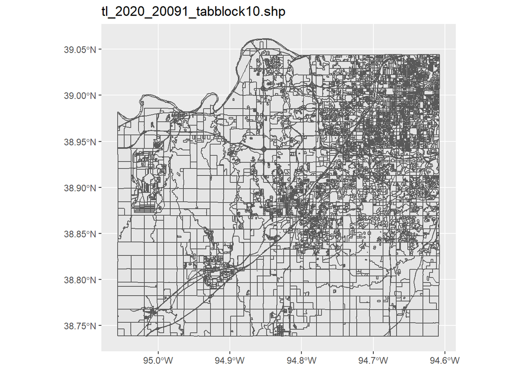

```r
s20091                                 %>%
   ggplot()                             +
      geom_sf(aes())                    +
      ggtitle(file_name)
```

### Leavenworth County, KS (20103)

```r
file_name <- "tl_2020_20103_tabblock10.shp"
path_name                              %>%
  paste(file_name, sep="/")            %>%
  st_read(stringsAsFactors=FALSE)       -> s20103
head(s20103)
```

```
## Simple feature collection with 6 features and 15 fields
## Geometry type: MULTIPOLYGON
## Dimension:     XY
## Bounding box:  xmin: -95.16178 ymin: 38.98214 xmax: -94.83459 ymax: 39.27063
## Geodetic CRS:  NAD83
##   STATEFP10 COUNTYFP10 TRACTCE10 BLOCKCE10         GEOID10     NAME10 MTFCC10
## 1        20        103    071000      1052 201030710001052 Block 1052   G5040
## 2        20        103    071203      1030 201030712031030 Block 1030   G5040
## 3        20        103    071102      2000 201030711022000 Block 2000   G5040
## 4        20        103    071600      1009 201030716001009 Block 1009   G5040
## 5        20        103    071400      3069 201030714003069 Block 3069   G5040
## 6        20        103    071600      1011 201030716001011 Block 1011   G5040
##   UR10 UACE10 UATYPE10 FUNCSTAT10 ALAND10 AWATER10  INTPTLAT10   INTPTLON10
## 1    R   <NA>     <NA>          S 4377101    29415 +39.2483471 -095.0948168
## 2    R   <NA>     <NA>          S  346111    29348 +39.1696559 -094.9173097
## 3    R   <NA>     <NA>          S       0   199830 +39.2656573 -094.8434508
## 4    R   <NA>     <NA>          S 5108354    49310 +39.1366023 -095.1413897
## 5    R   <NA>     <NA>          S       0   131490 +38.9867813 -094.9722350
## 6    R   <NA>     <NA>          S       0   160655 +39.1236053 -095.1518268
##                         geometry
## 1 MULTIPOLYGON (((-95.10569 3...
## 2 MULTIPOLYGON (((-94.91946 3...
## 3 MULTIPOLYGON (((-94.85215 3...
## 4 MULTIPOLYGON (((-95.16177 3...
## 5 MULTIPOLYGON (((-94.98199 3...
## 6 MULTIPOLYGON (((-95.15492 3...
```

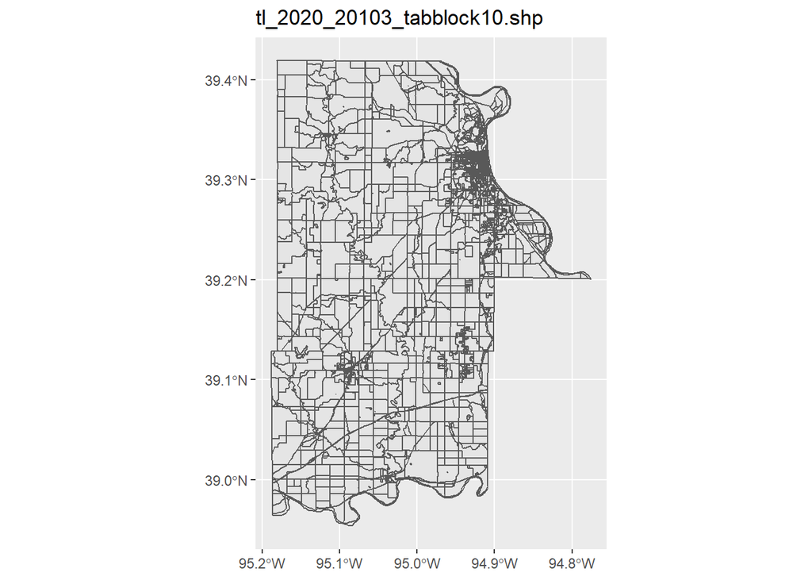

```r
s20103                                 %>%
   ggplot()                             +
      geom_sf(aes())                    +
      ggtitle(file_name)
```

### Miami County, KS (20121)

Miami County was included in earlier programs, but it is not needed for any of the work envisioned in this project.

### Wyandotte County, KS (20209)

```r
file_name <- "tl_2020_20209_tabblock10.shp"
path_name                              %>%
  paste(file_name, sep="/")            %>%
  st_read(stringsAsFactors=FALSE)       -> s20209
head(s20209)
```

```
## Simple feature collection with 6 features and 15 fields
## Geometry type: MULTIPOLYGON
## Dimension:     XY
## Bounding box:  xmin: -94.74515 ymin: 39.07598 xmax: -94.61217 ymax: 39.1025
## Geodetic CRS:  NAD83
##   STATEFP10 COUNTYFP10 TRACTCE10 BLOCKCE10         GEOID10     NAME10 MTFCC10
## 1        20        209    044004      1022 202090440041022 Block 1022   G5040
## 2        20        209    043804      1006 202090438041006 Block 1006   G5040
## 3        20        209    040002      1055 202090400021055 Block 1055   G5040
## 4        20        209    044004      1021 202090440041021 Block 1021   G5040
## 5        20        209    043804      1111 202090438041111 Block 1111   G5040
## 6        20        209    042501      1031 202090425011031 Block 1031   G5040
##   UR10 UACE10 UATYPE10 FUNCSTAT10 ALAND10 AWATER10  INTPTLAT10   INTPTLON10
## 1    R   <NA>     <NA>          S       0    38818 +39.0776326 -094.7434580
## 2    R   <NA>     <NA>          S       0     1526 +39.0932193 -094.7096391
## 3    U  43912        U          S       0     1699 +39.0989247 -094.6128253
## 4    R   <NA>     <NA>          S       0   234153 +39.0784838 -094.7383068
## 5    U  43912        U          S       0     2404 +39.0768528 -094.6497969
## 6    U  43912        U          S       0    13043 +39.1008795 -094.6147806
##                         geometry
## 1 MULTIPOLYGON (((-94.74515 3...
## 2 MULTIPOLYGON (((-94.70994 3...
## 3 MULTIPOLYGON (((-94.61343 3...
## 4 MULTIPOLYGON (((-94.74383 3...
## 5 MULTIPOLYGON (((-94.65003 3...
## 6 MULTIPOLYGON (((-94.61584 3...
```

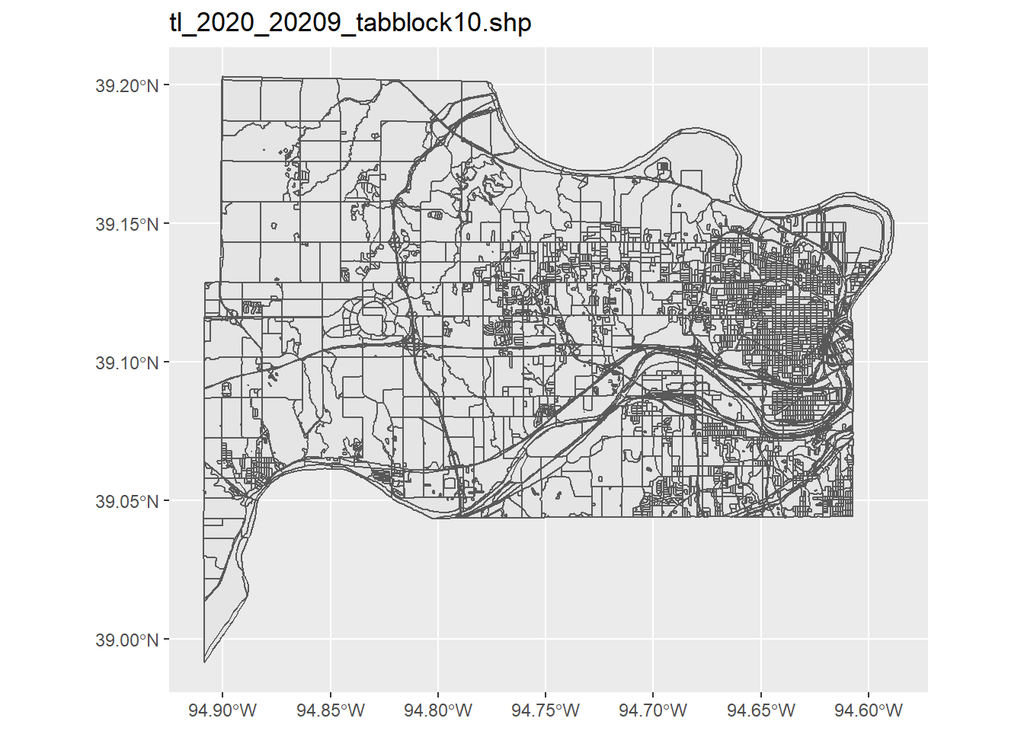

```r
s20209                                 %>%
   ggplot()                             +
      geom_sf(aes())                    +
      ggtitle(file_name)
```

### Cass County, MO (29037)

```r
file_name <- "tl_2020_29037_tabblock10.shp"
path_name                              %>%
  paste(file_name, sep="/")            %>%
  st_read(stringsAsFactors=FALSE)       -> s29037
head(s29037)
```

```
## Simple feature collection with 6 features and 15 fields
## Geometry type: POLYGON
## Dimension:     XY
## Bounding box:  xmin: -94.6091 ymin: 38.47632 xmax: -94.24056 ymax: 38.78994
## Geodetic CRS:  NAD83
##   STATEFP10 COUNTYFP10 TRACTCE10 BLOCKCE10         GEOID10     NAME10 MTFCC10
## 1        29        037    061001      1042 290370610011042 Block 1042   G5040
## 2        29        037    061001      1003 290370610011003 Block 1003   G5040
## 3        29        037    060305      1031 290370603051031 Block 1031   G5040
## 4        29        037    060700      3051 290370607003051 Block 3051   G5040
## 5        29        037    061100      2065 290370611002065 Block 2065   G5040
## 6        29        037    061200      3017 290370612003017 Block 3017   G5040
##   UR10 UACE10 UATYPE10 FUNCSTAT10 ALAND10 AWATER10  INTPTLAT10   INTPTLON10
## 1    R   <NA>     <NA>          S 3914613   127005 +38.7492476 -094.5991234
## 2    R   <NA>     <NA>          S 2395965    33908 +38.7816685 -094.5439887
## 3    R   <NA>     <NA>          S  612888    39219 +38.7862984 -094.4712714
## 4    R   <NA>     <NA>          S 1915854    31824 +38.6628656 -094.2481730
## 5    R   <NA>     <NA>          S 2570558     7985 +38.4834395 -094.5747748
## 6    R   <NA>     <NA>          S       0     1077 +38.4891357 -094.3413098
##                         geometry
## 1 POLYGON ((-94.6091 38.73864...
## 2 POLYGON ((-94.55124 38.7736...
## 3 POLYGON ((-94.47638 38.7830...
## 4 POLYGON ((-94.25914 38.6655...
## 5 POLYGON ((-94.58474 38.4767...
## 6 POLYGON ((-94.34148 38.4894...
```

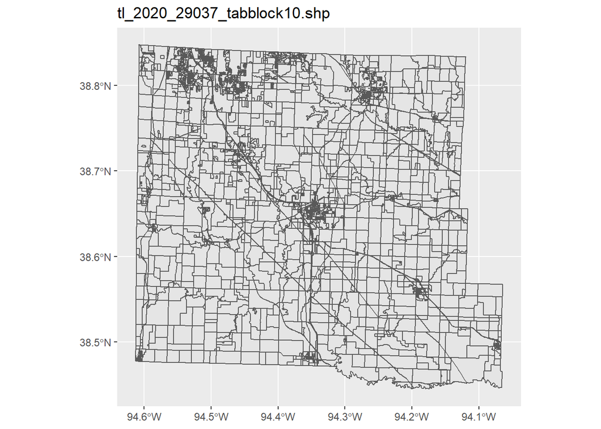

```r
s29037                                 %>%
   ggplot()                             +
      geom_sf(aes())                    +
      ggtitle(file_name)
```

### Clay County, MO (29047)

```r
file_name <- "tl_2020_29047_tabblock10.shp"
path_name                              %>%
  paste(file_name, sep="/")            %>%
  st_read(stringsAsFactors=FALSE)       -> s29047
head(s29047)
```

```
## Simple feature collection with 6 features and 15 fields
## Geometry type: MULTIPOLYGON
## Dimension:     XY
## Bounding box:  xmin: -94.57562 ymin: 39.24955 xmax: -94.23154 ymax: 39.4557
## Geodetic CRS:  NAD83
##   STATEFP10 COUNTYFP10 TRACTCE10 BLOCKCE10         GEOID10     NAME10 MTFCC10
## 1        29        047    021804      1044 290470218041044 Block 1044   G5040
## 2        29        047    021900      1010 290470219001010 Block 1010   G5040
## 3        29        047    021804      1034 290470218041034 Block 1034   G5040
## 4        29        047    021205      3012 290470212053012 Block 3012   G5040
## 5        29        047    021306      3011 290470213063011 Block 3011   G5040
## 6        29        047    021702      5024 290470217025024 Block 5024   G5040
##   UR10 UACE10 UATYPE10 FUNCSTAT10 ALAND10 AWATER10  INTPTLAT10   INTPTLON10
## 1    R   <NA>     <NA>          S 1723015    17630 +39.4152878 -094.3838094
## 2    R   <NA>     <NA>          S       0   674789 +39.4522978 -094.5345314
## 3    R   <NA>     <NA>          S       0    49531 +39.4212412 -094.4053333
## 4    U  43912        U          S 2556560      755 +39.2641401 -094.5453611
## 5    U  43912        U          S  298159    10481 +39.2744214 -094.5722027
## 6    U  28495        C          S       0    10703 +39.3220929 -094.2330251
##                         geometry
## 1 MULTIPOLYGON (((-94.38891 3...
## 2 MULTIPOLYGON (((-94.54208 3...
## 3 MULTIPOLYGON (((-94.40803 3...
## 4 MULTIPOLYGON (((-94.55263 3...
## 5 MULTIPOLYGON (((-94.57561 3...
## 6 MULTIPOLYGON (((-94.23401 3...
```

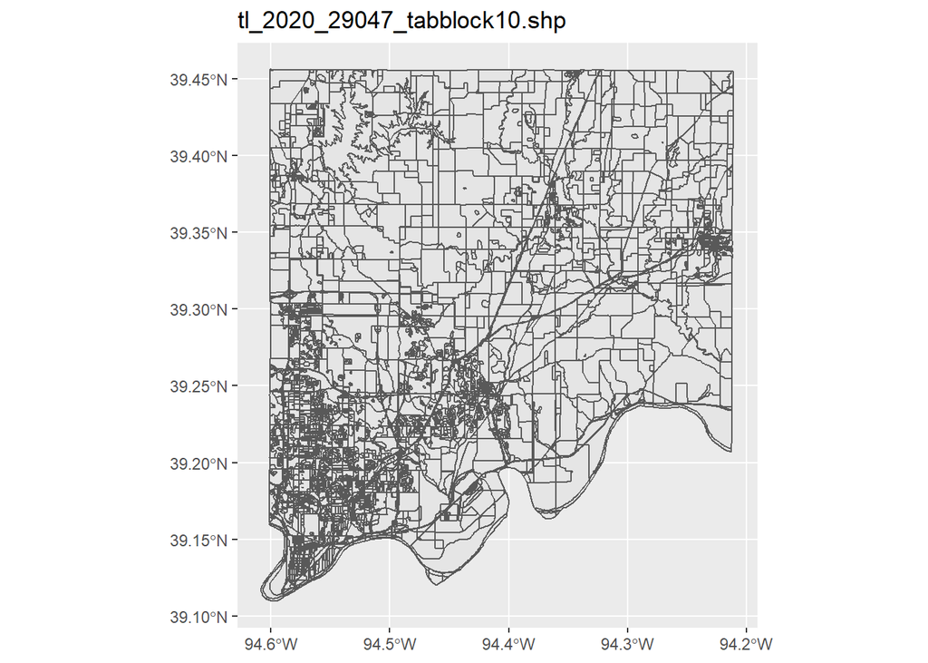

```r
s29047                                 %>%
   ggplot()                             +
      geom_sf(aes())                    +
      ggtitle(file_name)
```

### Jackson County, MO (29095)

```r
file_name <- "tl_2020_29095_tabblock10.shp"
path_name                              %>%
  paste(file_name, sep="/")            %>%
  st_read(stringsAsFactors=FALSE)       -> s29095
head(s29095)
```

```
## Simple feature collection with 6 features and 15 fields
## Geometry type: MULTIPOLYGON
## Dimension:     XY
## Bounding box:  xmin: -94.51318 ymin: 38.87511 xmax: -94.3153 ymax: 39.06195
## Geodetic CRS:  NAD83
##   STATEFP10 COUNTYFP10 TRACTCE10 BLOCKCE10         GEOID10     NAME10 MTFCC10
## 1        29        095    016300      1125 290950163001125 Block 1125   G5040
## 2        29        095    014400      1038 290950144001038 Block 1038   G5040
## 3        29        095    014502      2010 290950145022010 Block 2010   G5040
## 4        29        095    014804      1041 290950148041041 Block 1041   G5040
## 5        29        095    988300      1094 290959883001094 Block 1094   G5040
## 6        29        095    014400      2031 290950144002031 Block 2031   G5040
##   UR10 UACE10 UATYPE10 FUNCSTAT10 ALAND10 AWATER10  INTPTLAT10   INTPTLON10
## 1    U  43912        U          S  117034     5673 +39.0528357 -094.5102111
## 2    R   <NA>     <NA>          S  450173   193765 +38.9350560 -094.4605927
## 3    U  43912        U          S       0     2276 +39.0391290 -094.3493556
## 4    R   <NA>     <NA>          S 1153625      116 +39.0556505 -094.3275846
## 5    R   <NA>     <NA>          S       0    39797 +38.8789695 -094.4876980
## 6    U  48826        U          S       0    10685 +38.9429538 -094.4206606
##                         geometry
## 1 MULTIPOLYGON (((-94.51318 3...
## 2 MULTIPOLYGON (((-94.47153 3...
## 3 MULTIPOLYGON (((-94.34962 3...
## 4 MULTIPOLYGON (((-94.33685 3...
## 5 MULTIPOLYGON (((-94.48996 3...
## 6 MULTIPOLYGON (((-94.42184 3...
```

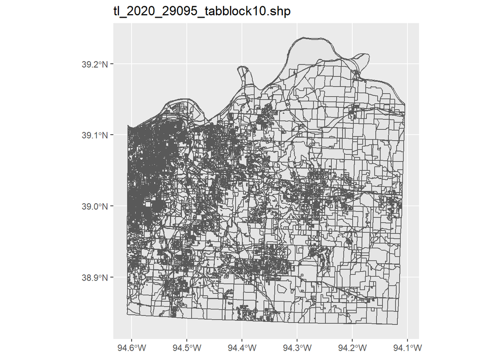

```r
s29095                                 %>%
   ggplot()                             +
      geom_sf(aes())                    +
      ggtitle(file_name)
```

### Platte County, MO (29165)

```r
file_name <- "tl_2020_29165_tabblock10.shp"
path_name                              %>%
  paste(file_name, sep="/")            %>%
  st_read(stringsAsFactors=FALSE)       -> s29165
head(s29165)
```

```
## Simple feature collection with 6 features and 15 fields
## Geometry type: POLYGON
## Dimension:     XY
## Bounding box:  xmin: -95.10289 ymin: 39.18567 xmax: -94.76669 ymax: 39.53335
## Geodetic CRS:  NAD83
##   STATEFP10 COUNTYFP10 TRACTCE10 BLOCKCE10         GEOID10     NAME10 MTFCC10
## 1        29        165    030700      3043 291650307003043 Block 3043   G5040
## 2        29        165    030401      3069 291650304013069 Block 3069   G5040
## 3        29        165    030401      4000 291650304014000 Block 4000   G5040
## 4        29        165    030600      4029 291650306004029 Block 4029   G5040
## 5        29        165    030306      3009 291650303063009 Block 3009   G5040
## 6        29        165    030700      3055 291650307003055 Block 3055   G5040
##   UR10 UACE10 UATYPE10 FUNCSTAT10 ALAND10 AWATER10  INTPTLAT10   INTPTLON10
## 1    R   <NA>     <NA>          S       0  1224755 +39.4905782 -095.0478408
## 2    R   <NA>     <NA>          S 5035438    30613 +39.3359829 -094.8656952
## 3    R   <NA>     <NA>          S 7188322    68926 +39.3250363 -094.8005402
## 4    R   <NA>     <NA>          S  179396    19105 +39.5220977 -094.7777989
## 5    R   <NA>     <NA>          S       0    64262 +39.1895201 -094.7690685
## 6    R   <NA>     <NA>          S 9719958    10791 +39.5039160 -094.9875711
##                         geometry
## 1 POLYGON ((-95.10289 39.5333...
## 2 POLYGON ((-94.89072 39.3425...
## 3 POLYGON ((-94.81771 39.3201...
## 4 POLYGON ((-94.78208 39.5208...
## 5 POLYGON ((-94.77074 39.1907...
## 6 POLYGON ((-95.00877 39.5092...
```

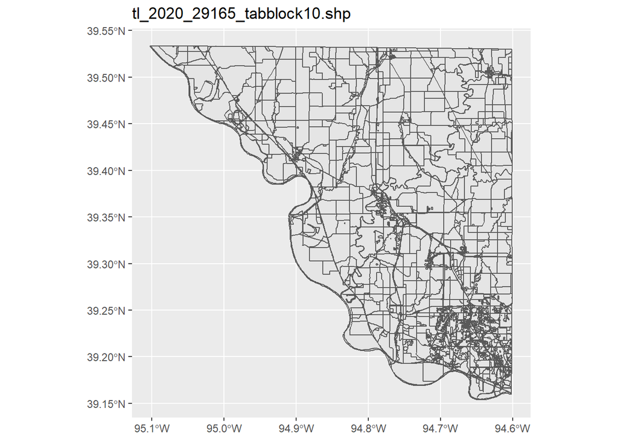

```r
s29165                                 %>%
   ggplot()                             +
      geom_sf(aes())                    +
      ggtitle(file_name)
```

### Store as an RData file

Placing the file in an RData format will speed up future use of this file.

```r
s20091                                 %>%
  bind_rows(s20103)                    %>%
  bind_rows(s20209)                    %>%
  bind_rows(s29037)                    %>%
  bind_rows(s29047)                    %>%
  bind_rows(s29095)                    %>%
  bind_rows(s29165)                    %>%
  mutate(label=GEOID10)                %>%
  rename(statefp=STATEFP10)            %>%
  rename(countyfp=COUNTYFP10)          %>%
  rename(tract=TRACTCE10)              %>%
  rename(block=BLOCKCE10)               -> bl
bl                                     %>%
  mutate(
    block_area=
      as.numeric(st_area(bl)))          -> bl
save(bl, file="../data/bl.RData")
```